# DSCI 503 – Project 01

## Part A: Stock Simulation Function

#### predicted price for 60 days of a stock with initial price 500, volatility of 0.3 and yearly yield of 8%

```python
import numpy as np
import math
import matplotlib.pyplot as plt
```

```python
def simulate_stock(start, rate, vol,days):
    daily_yeilds = np.random.normal((rate/252),vol/(252**0.5), size=days)
    cumulative_yields = np.cumsum(daily_yeilds)
    daily_multipliers= np.exp(cumulative_yields)
    daily_price = np.round(daily_multipliers * start,2)
    daily_price_array =  np.concatenate((start,daily_price),axis=None)
    return(daily_price_array)
```

### The function will now be tested below

```
[500.   515.75 509.98 505.08 495.1  503.42 482.15 498.47 491.51 494.63
 492.47 506.42 487.24 484.43 481.08 491.66 481.7  480.28 472.53 473.06
 478.45 468.75 479.15 487.54 492.35 500.96 494.69 493.7  485.2  482.9
 487.92 481.74 478.29 472.27 464.93 459.22 459.25 449.8  451.94 466.49
 473.23 471.66 463.97 457.61 472.63 473.23 467.72 469.56 488.73 489.99
 495.9  498.88 495.73 485.29 482.25 480.5  486.01 493.94 502.87 505.75
 514.44]
```

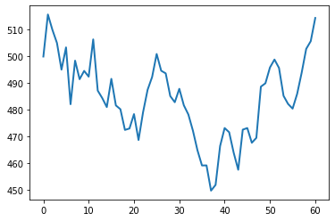

```python
np.random.seed(1)
stock_prices = simulate_stock(500,0.08,0.3,60)
print(stock_prices)
plt.plot( stock_prices, lw=2, ls='-')
```

## Part B: Annual Yield Function

#### finding the annual yield of a run 25 times and plotting it in a line plot to see different results

```python
def find_yield(run):
    annual_yield = round((math.log(run[60]/run[0]))*252/(len(run)-1),4)
    return(annual_yield)
```

### testing the function by running it on the previously simulated run

```python
print(find_yield(stock_prices))
```

```
0.1196
```

#### the next cell will explore the potential variability in our simulated runs by creating and plotting 25 simulated runs

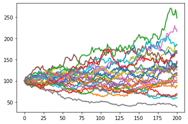

```python
yield_list = []
for i in range(0,25):
    stock_prices_run = simulate_stock(100,0.06,0.4,200)
    #print(stock_prices_run)
    yield_list.append(find_yield(stock_prices_run))
    plt.plot( stock_prices_run, lw=2, ls='-')
plt.show()
```

### the next cell will display the yields for the 25 simulated runs.

```python
print(yield_list)
```

```
[0.138, 0.2542, -0.0209, -0.0773, 0.0325, 0.1264, 0.191, 0.0362, 0.0441, -0.2572, 0.1562, -0.3088, -0.2668, -0.4192, -0.1753, 0.4825, 0.2067, -0.67, 0.2228, 0.3157, 0.0708, 0.0732, 0.2543, 0.302, 0.2161]
```

## Part C: Finding Seeds that Generate Specific Outcomes

### we simulated the stock price for 3 different stocks A,B and C for 100 days and put different seed to see which will give highest final value for each stock

### In the cell below, Stock A has the highest simulated final price.

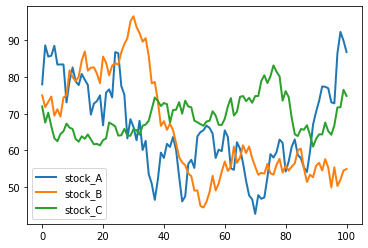

```python
np.random.seed(7)
stock_A = simulate_stock(78,0.04,1.2,100)
stock_B = simulate_stock(75,0.08,0.8,100)
stock_C = simulate_stock(72,0.16,0.6,100)
plt.plot( stock_A,label='stock_A', lw=2, ls='-')
plt.plot( stock_B,label='stock_B', lw=2, ls='-')
plt.plot( stock_C,label='stock_C', lw=2, ls='-')
plt.legend()
plt.show()
```

### In the cell below, Stock B has the highest simulated final price.

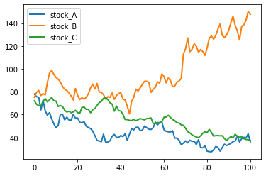

```python
np.random.seed(2)
stock_A = simulate_stock(78,0.04,1.2,100)
stock_B = simulate_stock(75,0.08,0.8,100)
stock_C = simulate_stock(72,0.16,0.6,100)
plt.plot( stock_A,label='stock_A', lw=2, ls='-')
plt.plot( stock_B,label='stock_B', lw=2, ls='-')
plt.plot( stock_C,label='stock_C', lw=2, ls='-')
plt.legend()
plt.show()
```

### In the cell below, Stock C has the highest simulated final price.

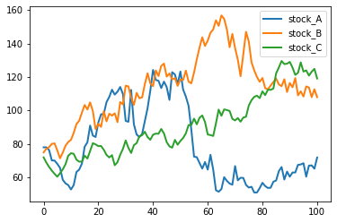

```python
np.random.seed(9)
stock_A = simulate_stock(78,0.04,1.2,100)
stock_B = simulate_stock(75,0.08,0.8,100)
stock_C = simulate_stock(72,0.16,0.6,100)
plt.plot( stock_A,label='stock_A', lw=2, ls='-')
plt.plot( stock_B,label='stock_B', lw=2, ls='-')
plt.plot( stock_C,label='stock_C', lw=2, ls='-')
plt.legend()
plt.show()
```

## Part D: Monte Carlo Simulation

### Running the same simulation 10k times to see how the data spreads out with high number of runs

```python
def monte_carlo(start, rate, vol, days, num_runs):
    final_prices = []
    annual_yields = []
    for run in range(0,num_runs):
        run_array = simulate_stock(start, rate, vol, days)
        final_yield = find_yield(run_array)
        annual_yields.append(final_yield)
        final_prices.append(run_array[days])
    return[np.array(final_prices),np.array(annual_yields)]
```

### testing the function by running a Monte Carlo simulation with a specific seed.

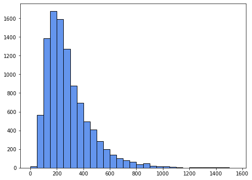

```python
np.random.seed(1)
[final_prices,annual_yields]=monte_carlo(200,0.1,0.4,500,10000)
plt.figure(figsize=[8,6])
plt.hist(final_prices, edgecolor='k', color='cornflowerblue', bins=np.arange(0, 1600, 50))
plt.show()
```

### displaying the 10th, 25th, 50th, 75th, and 90th percentiles of the simulated final prices.

```python
for percentile in [10,25,50,75,90]:
    print(percentile,"th percentile: ",round(np.percentile(final_prices,percentile),2),sep="")
```

```
10th percentile: 118.05
25th percentile: 165.57
50th percentile: 242.95
75th percentile: 357.56
90th percentile: 505.91
```

## Part E: Effects of Volatility

#### running monte carlo simulaition for two stocks with different volitility to see how it effects the spread of final price.

```python
np.random.seed(1)
[final_price_stock_A,annual_yeild_stock_A] = monte_carlo(100,0.12,0.3,150,10000)
[final_price_stock_B,annual_yeild_stock_B] = monte_carlo(100,0.12,0.7,150,10000)
print(" Average Annual Yield for A over 10000 runs:",round(sum(annual_yeild_stock_A)/10000,4))
print(" Average Annual Yield for A over 10000 runs:",round(sum(annual_yeild_stock_B)/10000,4))
```

```
 Average Annual Yield for A over 10000 runs: 0.0474
 Average Annual Yield for A over 10000 runs: 0.042
```

#### we will visually inspect the results of the two Monte Carlo simulations by plotting histograms of the final prices.

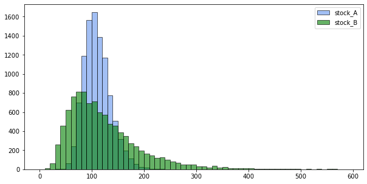

```python
plt.figure(figsize=[10,5])
plt.hist(final_price_stock_A,label='stock_A', edgecolor='k', color='cornflowerblue', bins=np.arange(0, 600, 10), alpha=0.6)
plt.hist(final_price_stock_B,label='stock_B', edgecolor='k', color='green', bins=np.arange(0, 600, 10),alpha=0.6)
plt.legend()
plt.show()
```

## Part F: Comparing Two Stocks

#### comparing two stocks to see how the prices are affected with different yeild and volitility by seeing how much of the final price is above 150 and below 100

```python
np.random.seed(1)
[final_price_stock_A,annual_yeild_stock_A] = monte_carlo(120,0.08,0.2,252,10000)
[final_price_stock_B,annual_yeild_stock_B] = monte_carlo(120,0.05,0.5,252,10000)
print("Proportions of runs in which...")
print("-------------------------------")
print('A ends above B:  ', (np.sum(final_price_stock_A > final_price_stock_B))/10000)
print("")
print('A ends above 150:', (np.sum(final_price_stock_A > 150))/10000)
print('B ends above 150:', (np.sum(final_price_stock_B > 150))/10000)
print("")
print('A ends below 100:', (np.sum(final_price_stock_A < 100))/10000)
print('B ends below 100:', (np.sum(final_price_stock_B < 100))/10000)
```

```
Proportions of runs in which...
-------------------------------
A ends above B:   0.5206

A ends above 150: 0.2338
B ends above 150: 0.3619

A ends below 100: 0.095
B ends below 100: 0.3195
```

## Part G: Expected Call Payoff

### calculating the average payoff of a call play of a stock with 10k runs

```python
np.random.seed(1)
[final_price,annual_yeild] = monte_carlo(200,0.11,0.4,365,10000)
print("")
final_price_summation = np.where(final_price - 225 <= 0,0,final_price-225)
print("the average call payoff over the 10,000 runs is: ",round(sum(final_price_summation)/10000,2))
```

```
the average call payoff over the 10,000 runs is:  67.75
```